# Differential Expression Analysis

# Introduction

This exercise will use published RNA Seq data (gene counts) from liver hepatocellular carcinoma (LIHC) tumor and normal liver tissue samples obtained from The Cancer Genome Atlas (TCGA). The aim of this exercise is to estimate the change in expression of each gene between normal tissue (NT) and primary tumor (TP) samples.

# R session setup

Data is classified as either normal tissue (NT) or primary tumor (TP). The count data files are located in the `data/gene_counts/` subdirectory in the `IDA_tutorial` directory.

The `gene_counts_LIHC.txt` dataset contains 100 samples (columns) with count values for 54,335 genes (rows). Samples are labeled as either “NT” (50 samples) or “TP” (50 samples) followed by a number. Note that the number does not correspond to anything meaningful (e.g., patient)

1. Start R and use `setwd()` (or Session > Set Working Directory > Choose Directory… from the top menu bar) to change the working directory to the `IDA_tutorial/` directory, which should contain a subdirectory named `data/`.
2. Load the `edgeR` package that will be used in this exercise:

```r
library(edgeR)
```

If you are unable to load the package, try to install it using the following commands:

```r
if (!requireNamespace("BiocManager", quietly = TRUE))
    install.packages("BiocManager")
BiocManager::install('edgeR')
```

If something fails, try to understand the error message and fix it. If you get stuck, ask for help :)

# Load data

3. Begin by loading the LIHC count data:

```r
count.data <- read.delim('data/gene_counts/gene_counts_LIHC.txt', stringsAsFactors=F, row.names=1)

# preview the first few rows and columns of the data
count.data[1:10,1:10]
```

```
##                    TP1   TP2   NT1   TP3   TP4   TP5   TP6   NT2   TP7   TP8
## ENSG00000000003   4652  3997  3638  4579  7124  1923  8742  3813  3560  5618
## ENSG00000000005      0     1     0    10     2     0     1     3     2     1
## ENSG00000000419    950  1270   660  1155  1241  1420  2211  1184  1174  2070
## ENSG00000000457    421   722   506   488  1770  1667  1166   573   461   729
## ENSG00000000460    281   244   175   120   547   652   480    60   127   255
## ENSG00000000938    254   153   128   263    78   330   132   412   196    96
## ENSG00000000971 181169 26196 58585 35111 49345 65112 66334 36690 58283 49596
## ENSG00000001036   5478  3480  1790  3926  3140  2611  4834  3111  3904  2862
## ENSG00000001084   2130  1796  5337  4485  3462 10833  4743  4854  5136  8824
## ENSG00000001167    986  2862   411   963  3244  1955  2304   843   560  1470
```

# Differential expression analysis

We will perform a differential expression (DE) analysis using the [edgeR](https://bioconductor.org/packages/release/bioc/html/edgeR.html). This exercise uses/explains only a little of edgeR, so it is strongly encouraged that you take a look at the [edgeR User’s Guide](https://bioconductor.org/packages/release/bioc/vignettes/edgeR/inst/doc/edgeRUsersGuide.pdf). Another package that is commonly used for DE analysis is [DESeq2](https://bioconductor.org/packages/release/bioc/html/DESeq2.html), which also has a very nice [User’s Guide](https://bioconductor.org/packages/release/bioc/vignettes/DESeq2/inst/doc/DESeq2.html). Although DESeq2 will not be covered in this exercise, we encourage you to check it out sometime.

## Data setup and exploration

We want to determine which genes are differentially expressed between two groups of samples - in this case, between “normal tissue” and “primary tumor” samples, which we have indicated by column names beginning with an “NT” or “TP”, respectively. We can take a quick look at the first 20 column names to preview what samples we have:

```r
colnames(count.data)[1:20]
```

```
##  [1] "TP1"  "TP2"  "NT1"  "TP3"  "TP4"  "TP5"  "TP6"  "NT2"  "TP7"  "TP8"
## [11] "TP9"  "TP10" "TP11" "TP12" "TP13" "TP14" "TP15" "TP16" "TP17" "TP18"
```

4. Generate a factor specifying the group to which each sample belongs:

```r
sample.groups <- factor(startsWith(colnames(count.data), 'TP'), labels=c('normal','tumor'))

# check that we set up the groups correctly
head(data.frame(sample=colnames(count.data), groups=sample.groups), 10)
```

```
##    sample groups
## 1     TP1  tumor
## 2     TP2  tumor
## 3     NT1 normal
## 4     TP3  tumor
## 5     TP4  tumor
## 6     TP5  tumor
## 7     TP6  tumor
## 8     NT2 normal
## 9     TP7  tumor
## 10    TP8  tumor
```

5. Create a `DGEList` object from the `count.data` dataframe and `sample.groups` factor:

```r
y <- DGEList(counts=count.data, group=sample.groups)
```

This DGEList object ‘holds’ the dataset to be analysed by edgeR and the subsequent calculations relevant for the analysis.

## Filtering and normalization

Often, RNA Seq data will contain low-count genes that are not expressed, or expressed at very low levels in many samples. The data for these genes is essentially noise that does not provide any meaningful information and should therefore be removed prior to DE analysis.

Although there is no single “correct” approach for removing low-count genes, a common technique involves removing those that are below some threshold in a given fraction of the samples.

6. Filter (remove) low-count genes from the count data, using a cut off of 10 reads:

```r
keep <- filterByExpr(y, min.count = 10)
y <- y[keep, , keep.lib.sizes=F]
```

The `filterByExpr` function will only keep genes that have at least `min.count` counts per million (CPM) in at least `n` samples, where `n` is the number of samples in the smallest group (we have equal group sizes of 50 samples in this case, so `n = 50`).

The `keep.lib.sizes=F` argument specifies that we want to recalculate the sample library sizes after removing the low-count genes from the data.

At this point, we can take a look at similarities and differences among different samples using a multidimensional scaling (MDS) plot:

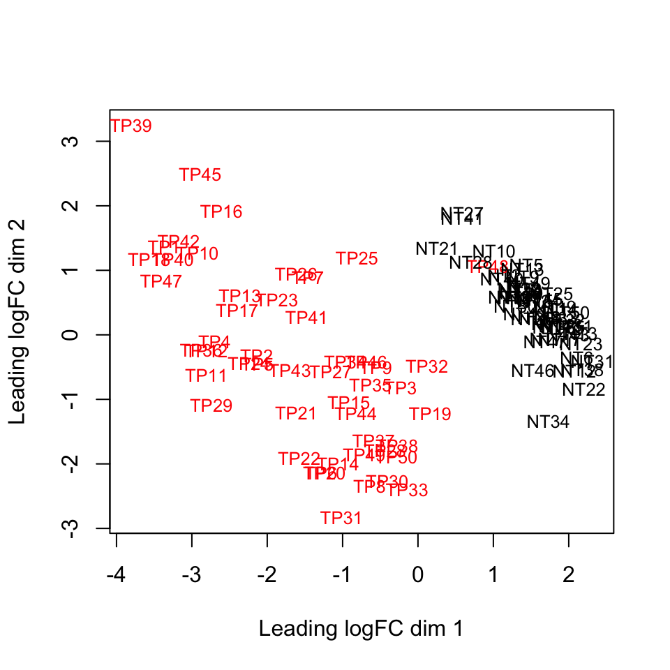

```r
plotMDS(y, cex=0.8, col=c('black','red')[sample.groups])  # "cex" sets the label font size
```

> **Question 1:** What is MDS, and how does it compare/contrast with related techniques, such as principal component analysis (PCA)?

[output not shown]

> **Question 2:** Does it look like our samples are grouping/separating well based on their sample type? Do you notice any other patterns in the data?

[output not shown]

The next step is to normalize the data by RNA composition, in order to address problems caused by the counts in a sample being dominated by only a few highly expressed genes. This can cause other genes in the sample to exhibit artificially low count values. The normalization factors calculated using the `calcNormFactors` function are then used to scale the counts to avoid such problems.

7. Calculate the normalization factors for each sample:

```r
y <- calcNormFactors(y)
```

To view the normalization factors calculated for each sample (as well as library sizes), we can take a look at the `samples` attribute of our DGEList, `y`:

```r
head(y$samples, 10)
```

```
##      group lib.size norm.factors
## TP1  tumor 53474030    1.1810255
## TP2  tumor 30437142    1.3801490
## NT1 normal 41348940    0.7942922
## TP3  tumor 59063874    1.0267874
## TP4  tumor 54711419    1.2638953
## TP5  tumor 53179430    1.6319847
## TP6  tumor 62875517    1.0669849
## NT2 normal 49537332    0.9655113
## TP7  tumor 41964089    1.3529653
## TP8  tumor 55361965    1.2974130
```

## Dispersion estimation

8. Estimate the dispersion across all genes:

```r
y <- estimateDisp(y)
```

We can also view the dispersion estimates using the BCV plot:

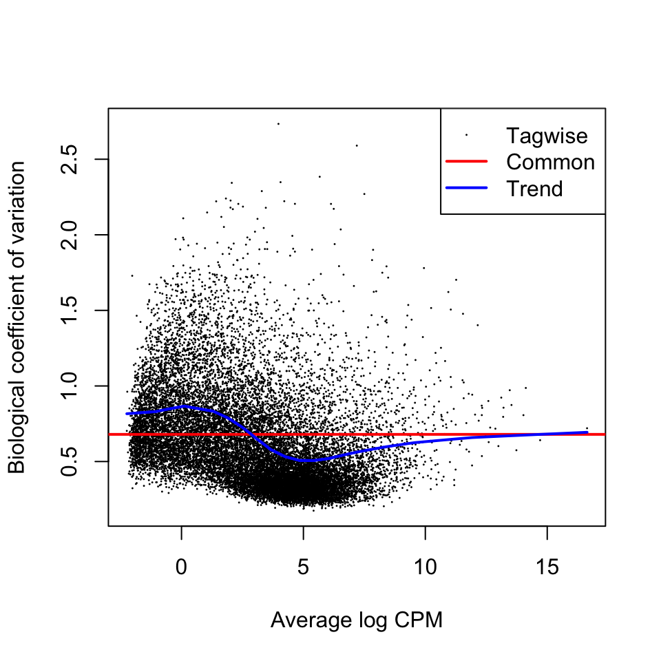

```r
plotBCV(y)
```

The results of this plot give us an idea about the variance across all genes that are lowly expressed all the way to highly expressed. Normally, the more lowly expressed genes will have larger variation compared to the more highly expressed genes. (“Tagwise” is gene by gene dispersion, “common” is dispersion aross the whole dataset and “trend” takes groups of similarily expressed genes plot dispersion.)

## Test for differential expression

9. Now we can test for DE genes using the `exactTest` function:

```r
et <- exactTest(y)
topTags(et)  # inspect the top-DE genes
```

```
## Comparison of groups:  tumor-normal
##                    logFC    logCPM       PValue          FDR
## ENSG00000187730 4.576823 0.9667413 5.073700e-80 9.126571e-76
## ENSG00000120334 2.618758 1.4329062 5.643799e-67 5.076033e-63
## ENSG00000117724 4.296046 3.8630214 1.494771e-65 8.962646e-62
## ENSG00000237649 4.064381 3.1356118 2.214456e-65 9.958407e-62
## ENSG00000225697 2.515989 3.5046256 2.204269e-64 7.930079e-61
## ENSG00000134057 3.519941 3.6248309 6.694647e-64 2.007055e-60
## ENSG00000198901 3.355621 3.2836991 1.572826e-63 4.041713e-60
## ENSG00000161888 3.608757 2.6072346 7.441567e-63 1.673236e-59
## ENSG00000146670 3.487770 2.6556046 1.730528e-62 3.458749e-59
## ENSG00000143228 4.392296 1.8028476 4.082811e-61 7.344160e-58
```

> **Question 3:** Take a closer look at these genes (you can use Google for help). Do you see anything interesting related to their functions?

| **Answer:** [Answers may vary…] |
| --- |

## Export results

The table of DE results is saved in `et$table`, but it does not contain the FDR-adjusted p-values. We can add this using the `p.adjust` function:

```r
res.table <- et$table
res.table$FDR <- p.adjust(res.table$PValue, 'BH')  # BH = Benjamini-Hochberg method
```

For a brief recap on why FDR adjustment is important, during multiple testing, take a look [here](https://www.explainxkcd.com/wiki/index.php/882:_Significant).

10. Export the results table to a .txt file:

```r
# note: this command will overwrite the existing pre-generated DE_results_glucose.txt file
write.table(res.table, file = 'data/DE_results/DE_results_LIHC.txt', quote=F, sep='\t')
```

# Data with multiple variables

In many cases, samples can be classified/grouped by more than one experimental variable/condition. For example, in a clinical trial, we may have unreated and treated subjects, as well as male and female. Often, we may want to look at differences between the different grouping types (untreated vs. treated, and male vs. female), or attempt to prevent factors associated with one variable influencing our analysis of another. For example, if we are only interested in the effect of the drug treatment, we don’t want differences in subject gender to bias the results.

Such cases can be approached using generalized linear models (GLMs). In this case, the variables deemed important by the scientist (that’s you) can be included together in a linear model, that is fit to the data, thus enabling estimation of expression changes based on those variables.

## Data setup and exploration

NOTE: This section is not yet complete.